# ipl_analysis

```python
import pandas as pd
import numpy as np
import seaborn as sns
import matplotlib.pyplot as plt
```

```python
ipl_df = pd.read_csv('matches.csv')
```

```python
ipl_df.info()
```

```
<class 'pandas.core.frame.DataFrame'>
RangeIndex: 756 entries, 0 to 755
Data columns (total 18 columns):
 #   Column           Non-Null Count  Dtype
---  ------           --------------  -----
 0   id               756 non-null    int64
 1   season           756 non-null    int64
 2   city             749 non-null    object
 3   date             756 non-null    object
 4   team1            756 non-null    object
 5   team2            756 non-null    object
 6   toss_winner      756 non-null    object
 7   toss_decision    756 non-null    object
 8   result           756 non-null    object
 9   dl_applied       756 non-null    int64
 10  winner           752 non-null    object
 11  win_by_runs      756 non-null    int64
 12  win_by_wickets   756 non-null    int64
 13  player_of_match  752 non-null    object
 14  venue            756 non-null    object
 15  umpire1          754 non-null    object
 16  umpire2          754 non-null    object
 17  umpire3          119 non-null    object
dtypes: int64(5), object(13)
memory usage: 106.4+ KB
```

```python
ipl_df.shape
```

```
(756, 18)
```

```python
ipl_df.sample(5)
```

|  | id | season | city | date | team1 | team2 | toss_winner | toss_decision | result | dl_applied | winner | win_by_runs | win_by_wickets | player_of_match | venue | umpire1 | umpire2 | umpire3 |
| --- | --- | --- | --- | --- | --- | --- | --- | --- | --- | --- | --- | --- | --- | --- | --- | --- | --- | --- |
| 551 | 552 | 2015 | Chandigarh | 2015-05-03 | Mumbai Indians | Kings XI Punjab | Mumbai Indians | bat | normal | 0 | Mumbai Indians | 23 | 0 | LMP Simmons | Punjab Cricket Association Stadium, Mohali | RK Illingworth | VA Kulkarni | NaN |
| 279 | 280 | 2011 | Bangalore | 2011-05-06 | Royal Challengers Bangalore | Kings XI Punjab | Kings XI Punjab | field | normal | 0 | Royal Challengers Bangalore | 85 | 0 | CH Gayle | M Chinnaswamy Stadium | Aleem Dar | RB Tiffin | NaN |
| 341 | 342 | 2012 | Delhi | 2012-04-27 | Delhi Daredevils | Mumbai Indians | Mumbai Indians | field | normal | 0 | Delhi Daredevils | 37 | 0 | V Sehwag | Feroz Shah Kotla | Aleem Dar | BNJ Oxenford | NaN |
| 82 | 83 | 2008 | Jaipur | 2008-05-04 | Chennai Super Kings | Rajasthan Royals | Chennai Super Kings | bat | normal | 0 | Rajasthan Royals | 0 | 8 | Sohail Tanvir | Sawai Mansingh Stadium | Asad Rauf | AV Jayaprakash | NaN |
| 566 | 567 | 2015 | Mumbai | 2015-05-14 | Mumbai Indians | Kolkata Knight Riders | Kolkata Knight Riders | field | normal | 0 | Mumbai Indians | 5 | 0 | HH Pandya | Wankhede Stadium | RK Illingworth | VA Kulkarni | NaN |

### dropping colummns which are of no use

```python
ipl_df.drop(columns=['umpire1','umpire2','umpire3'],inplace=True)
```

```python
ipl_df.columns
```

```
Index(['id', 'season', 'city', 'date', 'team1', 'team2', 'toss_winner',
       'toss_decision', 'result', 'dl_applied', 'winner', 'win_by_runs',
       'win_by_wickets', 'player_of_match', 'venue'],
      dtype='object')
```

```python
# checking the number of unique teams played in ipl

ipl_df.team1.unique()
```

```
array(['Sunrisers Hyderabad', 'Mumbai Indians', 'Gujarat Lions',
       'Rising Pune Supergiant', 'Royal Challengers Bangalore',
       'Kolkata Knight Riders', 'Delhi Daredevils', 'Kings XI Punjab',
       'Chennai Super Kings', 'Rajasthan Royals', 'Deccan Chargers',
       'Kochi Tuskers Kerala', 'Pune Warriors', 'Rising Pune Supergiants',
       'Delhi Capitals'], dtype=object)
```

### Data Cleaning which is required

i.Pune was represented by various Team Names as 'Rising Pune Supergiant', 'Pune Warriors' & 'Rising Pune Supergiants' so as a convinience we will changes these with the recent team representing Pune 'Rising Pune Supergiant'

ii.Earlier the team name for delhi was 'Delhi Daredevils' but later it was changed to 'Delhi Capitals' so we will replace the "delhi Daredevils' with 'Delhi Capitals'

iii.Bangalore was Renamed as Bengaluru in 2014 so we will change the Name for City Bangalore to Bengaluru

```python
ipl_df.team1.replace({'Rising Pune Supergiants':'Rising Pune Supergiant','Pune Warriors':'Rising Pune Supergiant','Delhi Daredevils':'Delhi Capitals'},inplace=True)
ipl_df.team2.replace({'Rising Pune Supergiants':'Rising Pune Supergiant','Pune Warriors':'Rising Pune Supergiant','Delhi Daredevils':'Delhi Capitals'},inplace=True)
ipl_df.toss_winner.replace({'Rising Pune Supergiants':'Rising Pune Supergiant','Pune Warriors':'Rising Pune Supergiant','Delhi Daredevils':'Delhi Capitals'},inplace=True)
ipl_df.winner.replace({'Rising Pune Supergiants':'Rising Pune Supergiant','Pune Warriors':'Rising Pune Supergiant','Delhi Daredevils':'Delhi Capitals'},inplace=True)

ipl_df.city.replace({'Bangalore':'Bengaluru'},inplace=True)
```

```python
ipl_df.team1.unique()
```

```
array(['Sunrisers Hyderabad', 'Mumbai Indians', 'Gujarat Lions',
       'Rising Pune Supergiant', 'Royal Challengers Bangalore',
       'Kolkata Knight Riders', 'Delhi Capitals', 'Kings XI Punjab',
       'Chennai Super Kings', 'Rajasthan Royals', 'Deccan Chargers',
       'Kochi Tuskers Kerala'], dtype=object)
```

```python
ipl_df.city.unique()
```

```
array(['Hyderabad', 'Pune', 'Rajkot', 'Indore', 'Bengaluru', 'Mumbai',
       'Kolkata', 'Delhi', 'Chandigarh', 'Kanpur', 'Jaipur', 'Chennai',
       'Cape Town', 'Port Elizabeth', 'Durban', 'Centurion',
       'East London', 'Johannesburg', 'Kimberley', 'Bloemfontein',
       'Ahmedabad', 'Cuttack', 'Nagpur', 'Dharamsala', 'Kochi',
       'Visakhapatnam', 'Raipur', 'Ranchi', 'Abu Dhabi', 'Sharjah', nan,
       'Mohali'], dtype=object)
```

```python
# Checking for missing values

ipl_df.isnull().sum()
```

```
id                 0
season             0
city               7
date               0
team1              0
team2              0
toss_winner        0
toss_decision      0
result             0
dl_applied         0
winner             4
win_by_runs        0
win_by_wickets     0
player_of_match    4
venue              0
dtype: int64
```

```python
null_df = ipl_df[ipl_df.isna().any(axis=1)]
null_df
```

|  | id | season | city | date | team1 | team2 | toss_winner | toss_decision | result | dl_applied | winner | win_by_runs | win_by_wickets | player_of_match | venue |
| --- | --- | --- | --- | --- | --- | --- | --- | --- | --- | --- | --- | --- | --- | --- | --- |
| 300 | 301 | 2011 | Delhi | 2011-05-21 | Delhi Capitals | Rising Pune Supergiant | Delhi Capitals | bat | no result | 0 | NaN | 0 | 0 | NaN | Feroz Shah Kotla |
| 461 | 462 | 2014 | NaN | 2014-04-19 | Mumbai Indians | Royal Challengers Bangalore | Royal Challengers Bangalore | field | normal | 0 | Royal Challengers Bangalore | 0 | 7 | PA Patel | Dubai International Cricket Stadium |
| 462 | 463 | 2014 | NaN | 2014-04-19 | Kolkata Knight Riders | Delhi Capitals | Kolkata Knight Riders | bat | normal | 0 | Delhi Capitals | 0 | 4 | JP Duminy | Dubai International Cricket Stadium |
| 466 | 467 | 2014 | NaN | 2014-04-23 | Chennai Super Kings | Rajasthan Royals | Rajasthan Royals | field | normal | 0 | Chennai Super Kings | 7 | 0 | RA Jadeja | Dubai International Cricket Stadium |
| 468 | 469 | 2014 | NaN | 2014-04-25 | Sunrisers Hyderabad | Delhi Capitals | Sunrisers Hyderabad | bat | normal | 0 | Sunrisers Hyderabad | 4 | 0 | AJ Finch | Dubai International Cricket Stadium |
| 469 | 470 | 2014 | NaN | 2014-04-25 | Mumbai Indians | Chennai Super Kings | Mumbai Indians | bat | normal | 0 | Chennai Super Kings | 0 | 7 | MM Sharma | Dubai International Cricket Stadium |
| 474 | 475 | 2014 | NaN | 2014-04-28 | Royal Challengers Bangalore | Kings XI Punjab | Kings XI Punjab | field | normal | 0 | Kings XI Punjab | 0 | 5 | Sandeep Sharma | Dubai International Cricket Stadium |
| 476 | 477 | 2014 | NaN | 2014-04-30 | Sunrisers Hyderabad | Mumbai Indians | Mumbai Indians | field | normal | 0 | Sunrisers Hyderabad | 15 | 0 | B Kumar | Dubai International Cricket Stadium |
| 545 | 546 | 2015 | Bengaluru | 2015-04-29 | Royal Challengers Bangalore | Rajasthan Royals | Rajasthan Royals | field | no result | 0 | NaN | 0 | 0 | NaN | M Chinnaswamy Stadium |
| 570 | 571 | 2015 | Bengaluru | 2015-05-17 | Delhi Capitals | Royal Challengers Bangalore | Royal Challengers Bangalore | field | no result | 0 | NaN | 0 | 0 | NaN | M Chinnaswamy Stadium |
| 744 | 11340 | 2019 | Bengaluru | 30/04/19 | Royal Challengers Bangalore | Rajasthan Royals | Rajasthan Royals | field | no result | 0 | NaN | 0 | 0 | NaN | M. Chinnaswamy Stadium |

From Above Observations We can See NaN values in various Columns like 'city', 'winner' ,'Player Of The Match'. But By Observation it is clear the NaN Values for columns like 'Winner' and 'Player Of The Match' are only for Case When Match had "No Result" so we Can assume the Match might have been a Draw or Cancelled Due to Some Weather Or Technical Conditions. While The Other Case 'City' Column has NaN values for Rows where Stadium Location is dubai. So we will Replace These NaN values and Insert "Dubai" as City in its Place

```python
ipl_df.loc[[461,462,466,468,469,474,476],'city'] = "Dubai"
```

```python
ipl_df.city.isnull().any()
```

```
False
```

```python
ipl_df.isnull().sum()
```

```
id                 0
season             0
city               0
date               0
team1              0
team2              0
toss_winner        0
toss_decision      0
result             0
dl_applied         0
winner             4
win_by_runs        0
win_by_wickets     0
player_of_match    4
venue              0
dtype: int64
```

```python
# Now we just have null values in column 'winner' and 'player_of_match'
```

```python
ipl_df.season.unique()
```

```
array([2017, 2008, 2009, 2010, 2011, 2012, 2013, 2014, 2015, 2016, 2018,
       2019], dtype=int64)
```

```python
ipl_df.id.count()
```

```
756
```

```python
ipl_df.result.value_counts()
```

```
normal       743
tie            9
no result      4
Name: result, dtype: int64
```

### There were 756 matches played from season 2008-19

### Out of 756 matches played 743 matches had normal result

```python
city = ipl_df.groupby('city')[['id']].count()
city = city.sort_values('id',ascending=False)
city.rename(columns={'id':'Matches'},inplace=True)
city = city.reset_index()
```

```python
city.style.background_gradient(cmap='Reds')
```

|  | city | Matches |
| --- | --- | --- |
| 0 | Mumbai | 101 |
| 1 | Bengaluru | 80 |
| 2 | Kolkata | 77 |
| 3 | Delhi | 74 |
| 4 | Hyderabad | 64 |
| 5 | Chennai | 57 |
| 6 | Jaipur | 47 |
| 7 | Chandigarh | 46 |
| 8 | Pune | 38 |
| 9 | Durban | 15 |
| 10 | Visakhapatnam | 13 |
| 11 | Centurion | 12 |
| 12 | Ahmedabad | 12 |
| 13 | Rajkot | 10 |
| 14 | Mohali | 10 |
| 15 | Dharamsala | 9 |
| 16 | Indore | 9 |
| 17 | Johannesburg | 8 |
| 18 | Ranchi | 7 |
| 19 | Port Elizabeth | 7 |
| 20 | Cape Town | 7 |
| 21 | Dubai | 7 |
| 22 | Cuttack | 7 |
| 23 | Abu Dhabi | 7 |
| 24 | Raipur | 6 |
| 25 | Sharjah | 6 |
| 26 | Kochi | 5 |
| 27 | Kanpur | 4 |
| 28 | Kimberley | 3 |
| 29 | Nagpur | 3 |
| 30 | East London | 3 |
| 31 | Bloemfontein | 2 |

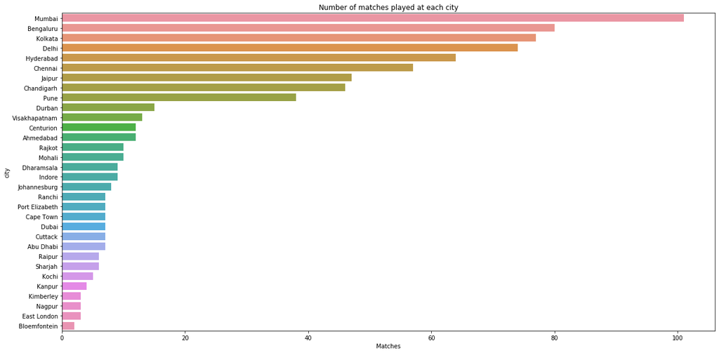

```python
plt.figure(figsize=(20,10))
plt.title('Number of matches played at each city')
sns.barplot(x='Matches', y='city', data=city);
```

```python
wins_df = ipl_df.groupby('winner')[['id']].count()
wins_df = wins_df.sort_values('id',ascending=False)
wins_df.rename(columns={'id':'Wins','winner':'Team'},inplace=True)
wins_df = wins_df.reset_index()
```

```python
wins_df
```

|  | winner | Wins |
| --- | --- | --- |
| 0 | Mumbai Indians | 109 |
| 1 | Chennai Super Kings | 100 |
| 2 | Kolkata Knight Riders | 92 |
| 3 | Royal Challengers Bangalore | 84 |
| 4 | Kings XI Punjab | 82 |
| 5 | Delhi Capitals | 77 |
| 6 | Rajasthan Royals | 75 |
| 7 | Sunrisers Hyderabad | 58 |
| 8 | Deccan Chargers | 29 |
| 9 | Rising Pune Supergiant | 27 |
| 10 | Gujarat Lions | 13 |
| 11 | Kochi Tuskers Kerala | 6 |

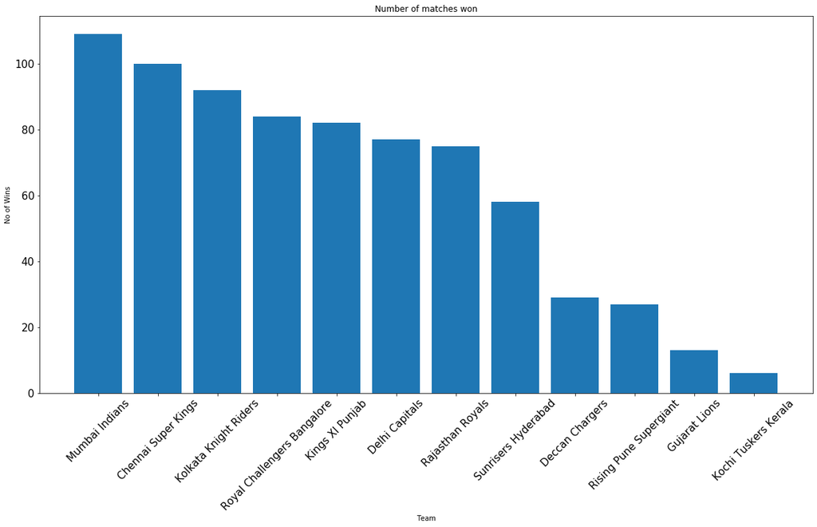

```python
# potting wins vs teams
plt.figure(figsize=(20,10))
plt.title("Number of matches won")
plt.bar(wins_df.winner,wins_df.Wins)
plt.xlabel('Team')
plt.xticks(rotation=45)
plt.tick_params(labelsize=15)
plt.ylabel('No of Wins');
```

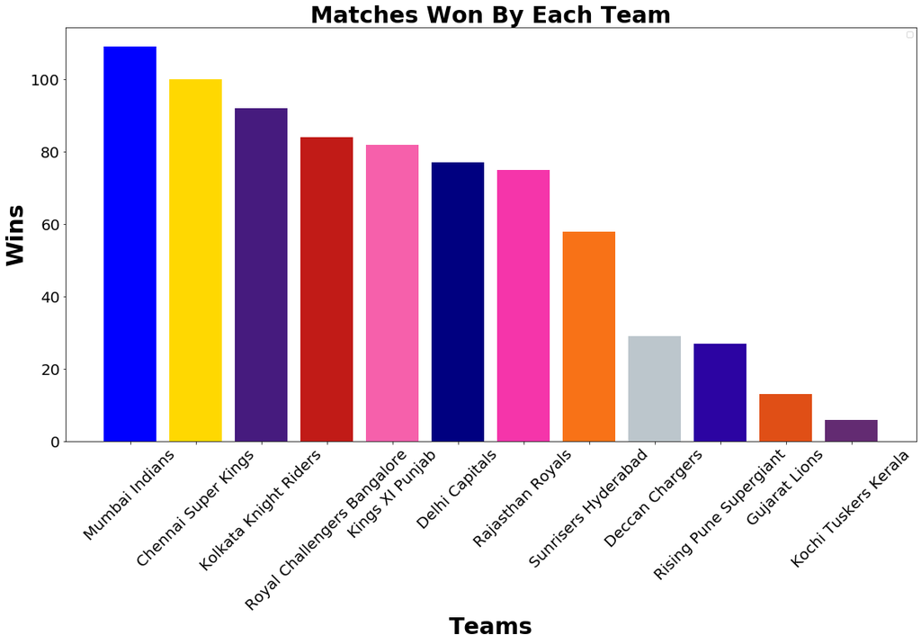

```python
#We will be using colour code of teams jersey to make it easily understandable
plt.figure(figsize=(20,10))
plt.legend(wins_df.winner,loc=1)
plt.xlabel('Teams',fontweight='bold',fontsize=30)
plt.ylabel('Wins',fontweight='bold',fontsize=30)
plt.tick_params(labelsize=20)
plt.xticks(rotation=45)
plt.title('Matches Won By Each Team',fontweight='bold',fontsize=30);
plt.bar(wins_df.winner, wins_df.Wins, color = ['blue','#FFD801','#461B7E','#C11B17','#F660AB','#000080','#F535AA','#F87217','#BCC6CC','#2C04A2','#E04F16','#632B72']);
```

### Preffered decision on winning the toss

```python
toss_count_df = ipl_df.groupby('toss_decision')[['id']].count()
```

```python
toss_count_df.rename(columns = {'toss_decision':'Decision' , 'id': 'Count'}, inplace = True)
```

```python
toss_count_df.columns
```

[output not shown]

```python
toss_count_df.reset_index()
```

|  | toss_decision | Count |
| --- | --- | --- |
| 0 | bat | 293 |
| 1 | field | 463 |

```python
toss_count_df['Count'] = toss_count_df['Count'] * 100 / toss_count_df['Count'].sum()
```

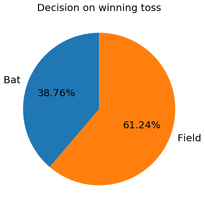

```python
plt.figure(figsize=(7,7))
plt.pie(toss_count_df.Count, labels=['Bat','Field'], autopct = '%1.2f%%', startangle=90, textprops={'fontsize': 20})
plt.title("Decision on winning toss",fontsize=20)

plt.show();
```

### Which toss decision was more victorious?

```python
field_df = ipl_df.loc[(ipl_df['toss_winner'] == ipl_df['winner']) & (ipl_df['toss_decision'] == 'field'), ['id' , 'winner' , 'toss_decision']]
```

```python
field_df.winner.count()
```

```
259
```

```python
bat_df = ipl_df.loc[(ipl_df['toss_winner'] == ipl_df['winner']) & (ipl_df['toss_decision'] == 'bat'), ['id' , 'winner' , 'toss_decision']]
```

```python
bat_df.winner.count()
```

```
134
```

```python
result_df = field_df.append(bat_df)
```

```python
result_df = result_df.groupby('toss_decision')[['id']].count()
```

```python
result_df
```

| toss_decision | id |
| --- | --- |
| bat | 134 |
| field | 259 |

```python
result_df = result_df.reset_index()
```

```python
result_df.rename(columns = {'id':'Total' , 'toss_decision':'Decision'}, inplace=True)
result_df
```

|  | Decision | Total |
| --- | --- | --- |
| 0 | bat | 134 |
| 1 | field | 259 |

```python
toss_tally_df = ipl_df.groupby('toss_decision')[['id']].count()
toss_tally_df = toss_tally_df.reset_index()
toss_tally_df.rename(columns = {'toss_decision':'Decision' , 'id': 'Count'}, inplace = True)
toss_tally_df
```

|  | Decision | Count |
| --- | --- | --- |
| 0 | bat | 293 |
| 1 | field | 463 |

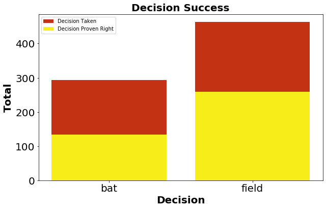

```python
plt.figure(figsize=(10,6))
plt.title("Decision Success",fontweight='bold',fontsize=20)
plt.xlabel('Decision',fontweight='bold',fontsize=20)
plt.ylabel('Total',fontweight='bold',fontsize=20)
plt.tick_params(labelsize=20)
plt.bar(toss_tally_df.Decision,  toss_tally_df.Count, color =['#C23213','#C23213'] );
plt.bar(result_df.Decision , result_df.Total, color =['#F7ED18','#F7ED18']);
plt.legend(['Decision Taken', 'Decision Proven Right']);
```

We can See the Fielding decision on winning toss has not only been most Preferred one But it has also proven to be a good Decision as almost 60% of the Time it is Proved Right

### At which venue most matches has been played?

```python
ipl_df.head()
```

|  | id | season | city | date | team1 | team2 | toss_winner | toss_decision | result | dl_applied | winner | win_by_runs | win_by_wickets | player_of_match | venue |
| --- | --- | --- | --- | --- | --- | --- | --- | --- | --- | --- | --- | --- | --- | --- | --- |
| 0 | 1 | 2017 | Hyderabad | 2017-04-05 | Sunrisers Hyderabad | Royal Challengers Bangalore | Royal Challengers Bangalore | field | normal | 0 | Sunrisers Hyderabad | 35 | 0 | Yuvraj Singh | Rajiv Gandhi International Stadium, Uppal |
| 1 | 2 | 2017 | Pune | 2017-04-06 | Mumbai Indians | Rising Pune Supergiant | Rising Pune Supergiant | field | normal | 0 | Rising Pune Supergiant | 0 | 7 | SPD Smith | Maharashtra Cricket Association Stadium |
| 2 | 3 | 2017 | Rajkot | 2017-04-07 | Gujarat Lions | Kolkata Knight Riders | Kolkata Knight Riders | field | normal | 0 | Kolkata Knight Riders | 0 | 10 | CA Lynn | Saurashtra Cricket Association Stadium |
| 3 | 4 | 2017 | Indore | 2017-04-08 | Rising Pune Supergiant | Kings XI Punjab | Kings XI Punjab | field | normal | 0 | Kings XI Punjab | 0 | 6 | GJ Maxwell | Holkar Cricket Stadium |
| 4 | 5 | 2017 | Bengaluru | 2017-04-08 | Royal Challengers Bangalore | Delhi Capitals | Royal Challengers Bangalore | bat | normal | 0 | Royal Challengers Bangalore | 15 | 0 | KM Jadhav | M Chinnaswamy Stadium |

```python
ipl_df.venue.nunique()
```

```
41
```

```python
# There are 41 different venues where matches have been played
```

```python
venues_df = ipl_df.groupby('venue')[['id']].count()
venues_df = venues_df.sort_values('id', ascending = False).reset_index()
venues_df.rename(columns = {'id':'Matches_Played' , 'venue':'Stadium'},inplace=True)

venues_df
```

|  | Stadium | Matches_Played |
| --- | --- | --- |
| 0 | Eden Gardens | 77 |
| 1 | Wankhede Stadium | 73 |
| 2 | M Chinnaswamy Stadium | 73 |
| 3 | Feroz Shah Kotla | 67 |
| 4 | Rajiv Gandhi International Stadium, Uppal | 56 |
| 5 | MA Chidambaram Stadium, Chepauk | 49 |
| 6 | Sawai Mansingh Stadium | 47 |
| 7 | Punjab Cricket Association Stadium, Mohali | 35 |
| 8 | Maharashtra Cricket Association Stadium | 21 |
| 9 | Dr DY Patil Sports Academy | 17 |
| 10 | Subrata Roy Sahara Stadium | 17 |
| 11 | Kingsmead | 15 |
| 12 | Punjab Cricket Association IS Bindra Stadium, ... | 14 |
| 13 | SuperSport Park | 12 |
| 14 | Sardar Patel Stadium, Motera | 12 |
| 15 | Dr. Y.S. Rajasekhara Reddy ACA-VDCA Cricket St... | 11 |
| 16 | Brabourne Stadium | 11 |
| 17 | Saurashtra Cricket Association Stadium | 10 |
| 18 | Himachal Pradesh Cricket Association Stadium | 9 |
| 19 | Holkar Cricket Stadium | 9 |
| 20 | Rajiv Gandhi Intl. Cricket Stadium | 8 |
| 21 | New Wanderers Stadium | 8 |
| 22 | M. A. Chidambaram Stadium | 8 |
| 23 | IS Bindra Stadium | 7 |
| 24 | Newlands | 7 |
| 25 | Feroz Shah Kotla Ground | 7 |
| 26 | Barabati Stadium | 7 |
| 27 | M. Chinnaswamy Stadium | 7 |
| 28 | St George's Park | 7 |
| 29 | JSCA International Stadium Complex | 7 |
| 30 | Dubai International Cricket Stadium | 7 |
| 31 | Sheikh Zayed Stadium | 7 |
| 32 | Sharjah Cricket Stadium | 6 |
| 33 | Shaheed Veer Narayan Singh International Stadium | 6 |
| 34 | Nehru Stadium | 5 |
| 35 | Green Park | 4 |
| 36 | Buffalo Park | 3 |
| 37 | De Beers Diamond Oval | 3 |
| 38 | Vidarbha Cricket Association Stadium, Jamtha | 3 |
| 39 | OUTsurance Oval | 2 |
| 40 | ACA-VDCA Stadium | 2 |

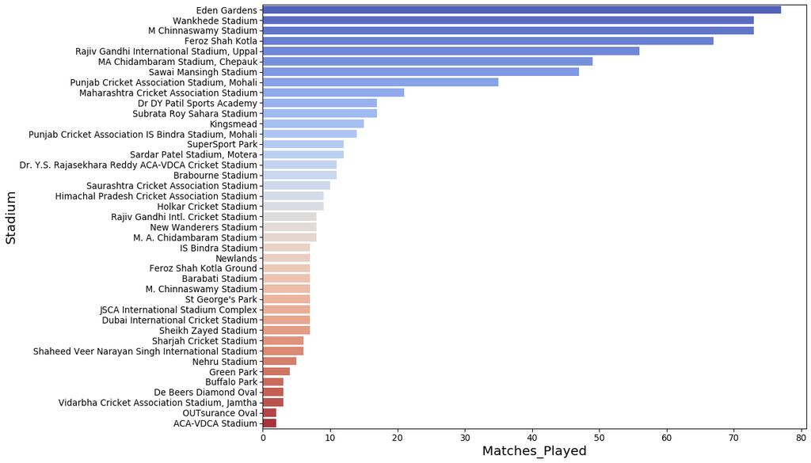

```python
plt.figure(figsize=(15,12))
sns.set_context('paper', font_scale=1.5)
plt.xlabel('Matches Played',size=20)
plt.ylabel('Stadium', size = 20)
sns.barplot(x='Matches_Played', y='Stadium', data=venues_df,palette='coolwarm');
```

### Which player has been awarded most man of the match awards?

```python
ipl_df.head(5)
```

|  | id | season | city | date | team1 | team2 | toss_winner | toss_decision | result | dl_applied | winner | win_by_runs | win_by_wickets | player_of_match | venue |
| --- | --- | --- | --- | --- | --- | --- | --- | --- | --- | --- | --- | --- | --- | --- | --- |
| 0 | 1 | 2017 | Hyderabad | 2017-04-05 | Sunrisers Hyderabad | Royal Challengers Bangalore | Royal Challengers Bangalore | field | normal | 0 | Sunrisers Hyderabad | 35 | 0 | Yuvraj Singh | Rajiv Gandhi International Stadium, Uppal |
| 1 | 2 | 2017 | Pune | 2017-04-06 | Mumbai Indians | Rising Pune Supergiant | Rising Pune Supergiant | field | normal | 0 | Rising Pune Supergiant | 0 | 7 | SPD Smith | Maharashtra Cricket Association Stadium |
| 2 | 3 | 2017 | Rajkot | 2017-04-07 | Gujarat Lions | Kolkata Knight Riders | Kolkata Knight Riders | field | normal | 0 | Kolkata Knight Riders | 0 | 10 | CA Lynn | Saurashtra Cricket Association Stadium |
| 3 | 4 | 2017 | Indore | 2017-04-08 | Rising Pune Supergiant | Kings XI Punjab | Kings XI Punjab | field | normal | 0 | Kings XI Punjab | 0 | 6 | GJ Maxwell | Holkar Cricket Stadium |
| 4 | 5 | 2017 | Bengaluru | 2017-04-08 | Royal Challengers Bangalore | Delhi Capitals | Royal Challengers Bangalore | bat | normal | 0 | Royal Challengers Bangalore | 15 | 0 | KM Jadhav | M Chinnaswamy Stadium |

```python
man_of_match_df = ipl_df.groupby('player_of_match')[['id']].count()
```

```python
man_of_match_df = man_of_match_df.sort_values('id',ascending = False).reset_index()
```

```python
man_of_match_df.rename(columns = {'id':'Awards', 'player_of_match': 'Player'},inplace=True)
```

```python
man_of_match_df = man_of_match_df.head(10)
man_of_match_df
```

|  | Player | Awards |
| --- | --- | --- |
| 0 | CH Gayle | 21 |
| 1 | AB de Villiers | 20 |
| 2 | MS Dhoni | 17 |
| 3 | DA Warner | 17 |
| 4 | RG Sharma | 17 |
| 5 | YK Pathan | 16 |
| 6 | SR Watson | 15 |
| 7 | SK Raina | 14 |
| 8 | G Gambhir | 13 |
| 9 | MEK Hussey | 12 |

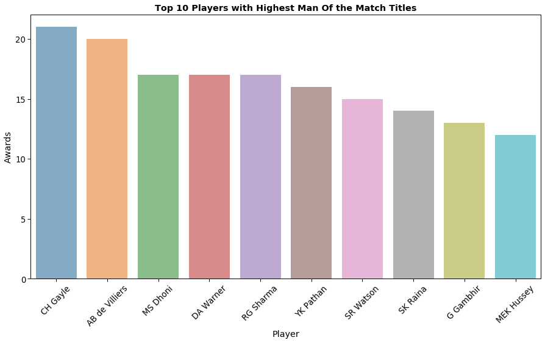

```python
plt.figure(figsize=(15,8))
plt.title("Top 10 Players with Highest Man Of the Match Titles",fontweight='bold' )
plt.xticks(rotation=45)
plt.yticks(ticks=np.arange(0,25,5))
plt.ylabel('No. of Awards')
plt.xlabel('Players')
sns.barplot(x=man_of_match_df.Player,y=man_of_match_df.Awards, alpha=0.6);
```

### Team with most number of titles

```python
final_df = ipl_df.groupby('season').tail(1).copy()
```

```python
final_df = final_df.sort_values('season')
```

```python
final_df
```

|  | id | season | city | date | team1 | team2 | toss_winner | toss_decision | result | dl_applied | winner | win_by_runs | win_by_wickets | player_of_match | venue |
| --- | --- | --- | --- | --- | --- | --- | --- | --- | --- | --- | --- | --- | --- | --- | --- |
| 116 | 117 | 2008 | Mumbai | 2008-06-01 | Chennai Super Kings | Rajasthan Royals | Rajasthan Royals | field | normal | 0 | Rajasthan Royals | 0 | 3 | YK Pathan | Dr DY Patil Sports Academy |
| 173 | 174 | 2009 | Johannesburg | 2009-05-24 | Deccan Chargers | Royal Challengers Bangalore | Royal Challengers Bangalore | field | normal | 0 | Deccan Chargers | 6 | 0 | A Kumble | New Wanderers Stadium |
| 233 | 234 | 2010 | Mumbai | 2010-04-25 | Chennai Super Kings | Mumbai Indians | Chennai Super Kings | bat | normal | 0 | Chennai Super Kings | 22 | 0 | SK Raina | Dr DY Patil Sports Academy |
| 306 | 307 | 2011 | Chennai | 2011-05-28 | Chennai Super Kings | Royal Challengers Bangalore | Chennai Super Kings | bat | normal | 0 | Chennai Super Kings | 58 | 0 | M Vijay | MA Chidambaram Stadium, Chepauk |
| 380 | 381 | 2012 | Chennai | 2012-05-27 | Chennai Super Kings | Kolkata Knight Riders | Chennai Super Kings | bat | normal | 0 | Kolkata Knight Riders | 0 | 5 | MS Bisla | MA Chidambaram Stadium, Chepauk |
| 456 | 457 | 2013 | Kolkata | 2013-05-26 | Mumbai Indians | Chennai Super Kings | Mumbai Indians | bat | normal | 0 | Mumbai Indians | 23 | 0 | KA Pollard | Eden Gardens |
| 516 | 517 | 2014 | Bengaluru | 2014-06-01 | Kings XI Punjab | Kolkata Knight Riders | Kolkata Knight Riders | field | normal | 0 | Kolkata Knight Riders | 0 | 3 | MK Pandey | M Chinnaswamy Stadium |
| 575 | 576 | 2015 | Kolkata | 2015-05-24 | Mumbai Indians | Chennai Super Kings | Chennai Super Kings | field | normal | 0 | Mumbai Indians | 41 | 0 | RG Sharma | Eden Gardens |
| 635 | 636 | 2016 | Bengaluru | 2016-05-29 | Sunrisers Hyderabad | Royal Challengers Bangalore | Sunrisers Hyderabad | bat | normal | 0 | Sunrisers Hyderabad | 8 | 0 | BCJ Cutting | M Chinnaswamy Stadium |
| 58 | 59 | 2017 | Hyderabad | 2017-05-21 | Mumbai Indians | Rising Pune Supergiant | Mumbai Indians | bat | normal | 0 | Mumbai Indians | 1 | 0 | KH Pandya | Rajiv Gandhi International Stadium, Uppal |
| 695 | 7953 | 2018 | Mumbai | 27/05/18 | Sunrisers Hyderabad | Chennai Super Kings | Chennai Super Kings | field | normal | 0 | Chennai Super Kings | 0 | 8 | SR Watson | Wankhede Stadium |
| 755 | 11415 | 2019 | Hyderabad | 12/05/19 | Mumbai Indians | Chennai Super Kings | Mumbai Indians | bat | normal | 0 | Mumbai Indians | 1 | 0 | JJ Bumrah | Rajiv Gandhi Intl. Cricket Stadium |

```python
final_df.groupby('winner')[['id']].count()
```

| winner | id |
| --- | --- |
| Chennai Super Kings | 3 |
| Deccan Chargers | 1 |
| Kolkata Knight Riders | 2 |
| Mumbai Indians | 4 |
| Rajasthan Royals | 1 |
| Sunrisers Hyderabad | 1 |

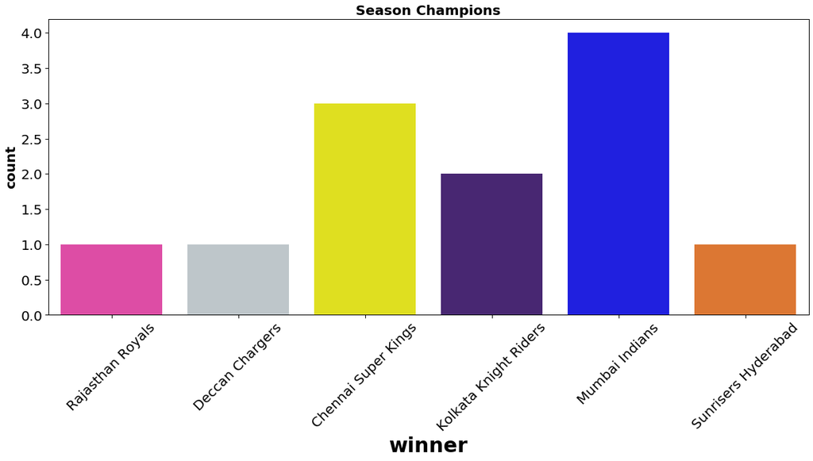

```python
plt.figure(figsize=(20,8))
plt.title("Season Champions",fontweight='bold',fontsize=20)
plt.xlabel('Teams',fontweight='bold',fontsize=30)
plt.ylabel('Total Seasons',fontweight='bold',fontsize=20)
plt.xticks(rotation='45')
plt.tick_params(labelsize=20)

sns.countplot(x=final_df['winner'],palette=['#F535AA','#BCC6CC','yellow','#461B7E','blue','#F87217']);
```